# automatization_notebook_02

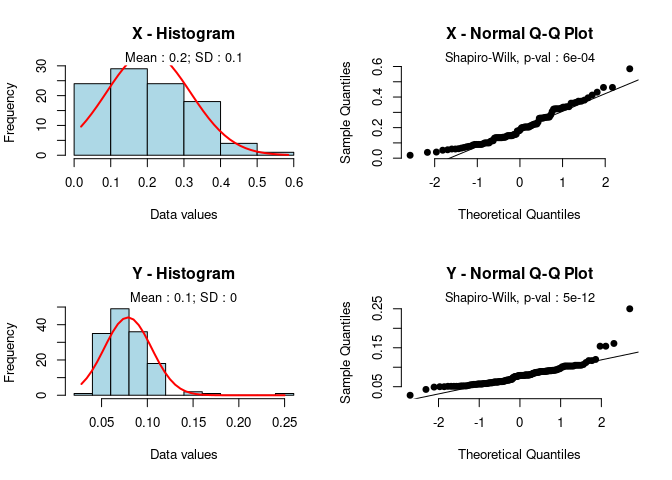

```r
sepfoo(Category, Data_Major_Minerals_Copper)
```

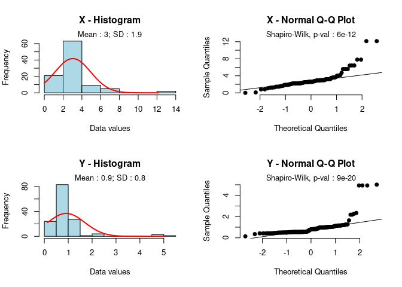

```r
sepfoo(Category, Data_Major_Minerals_Iron)
```

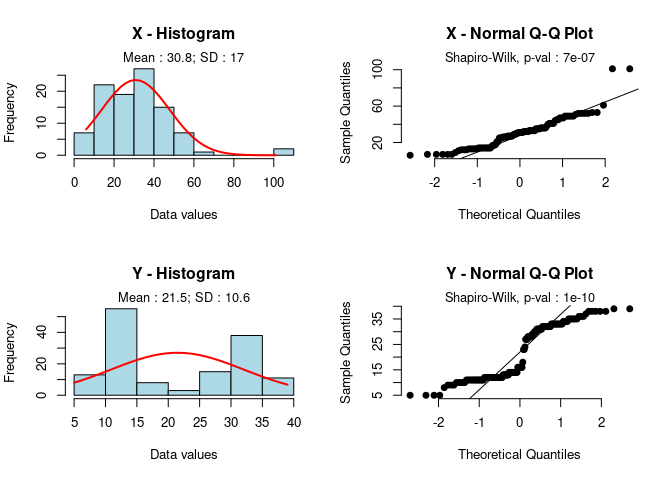

```r
sepfoo(Category, Data_Major_Minerals_Magnesium)
```

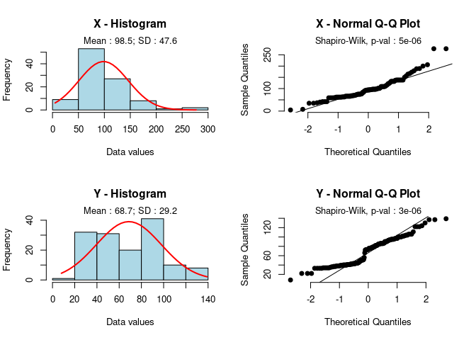

```r
sepfoo(Category, Data_Major_Minerals_Phosphorus)
```

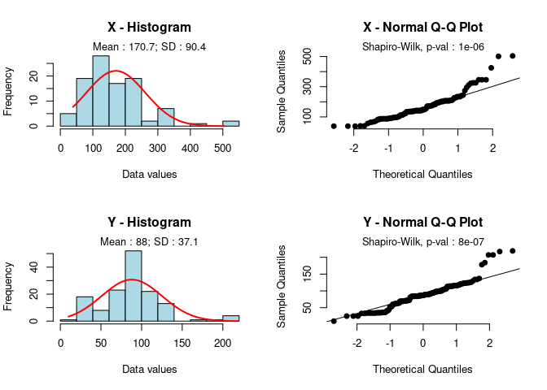

```r
sepfoo(Category, Data_Major_Minerals_Potassium)
```

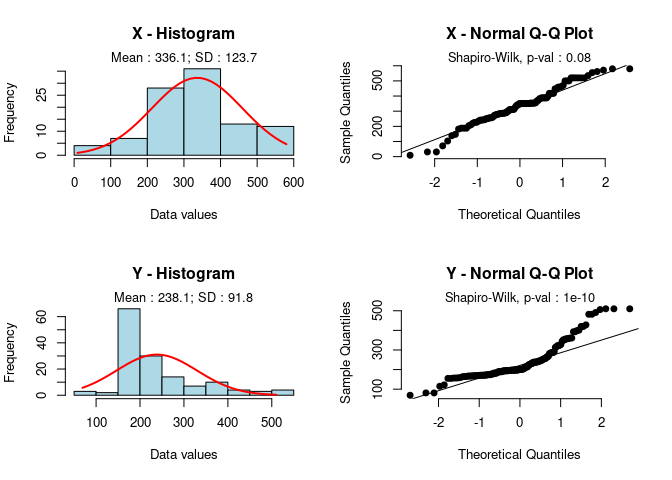

```r
sepfoo(Category, Data_Major_Minerals_Sodium)
```

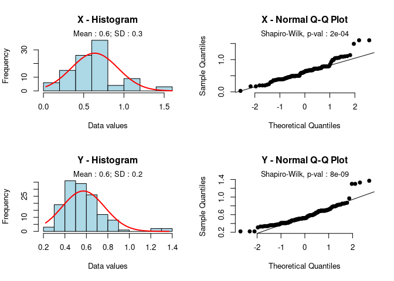

```r
sepfoo(Category, Data_Major_Minerals_Zinc)
```

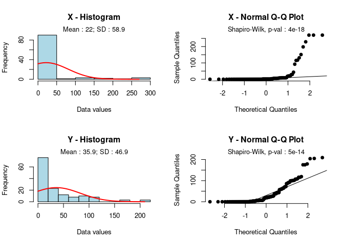

```r
sepfoo(Category, Data_Vitamins_Vitamin_A_RAE)
```

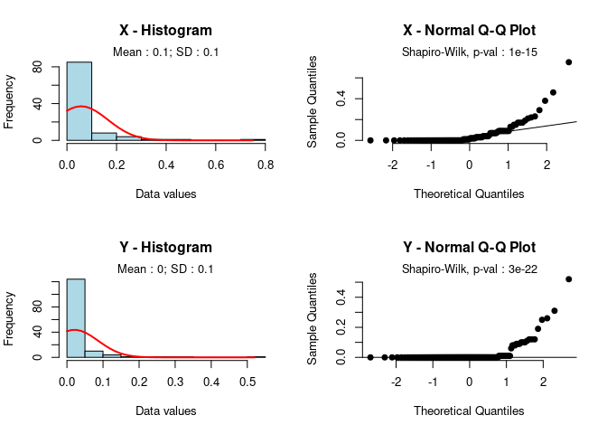

```r
sepfoo(Category, Data_Vitamins_Vitamin_B12)
```

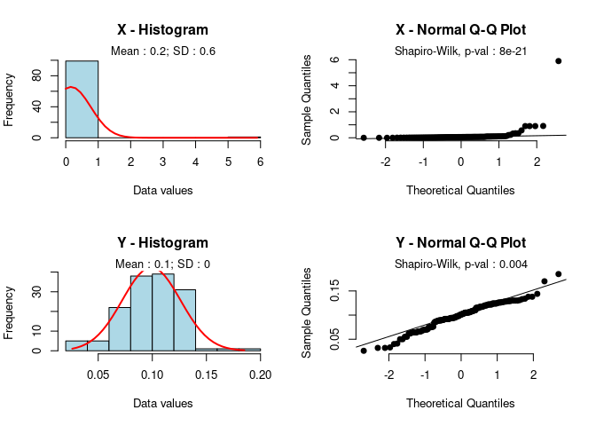

```r
sepfoo(Category, Data_Vitamins_Vitamin_B6)
```

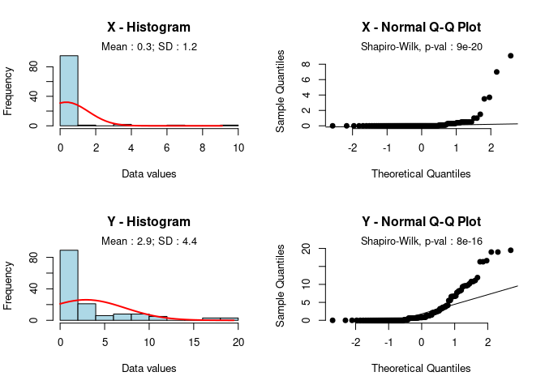

```r
sepfoo(Category, Data_Vitamins_Vitamin_C)
```

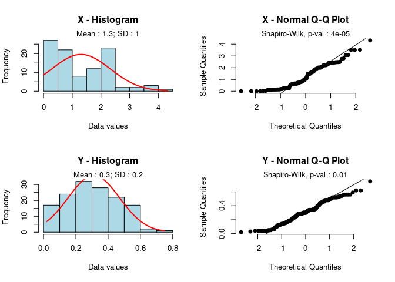

```r
sepfoo(Category, Data_Vitamins_Vitamin_E)
```

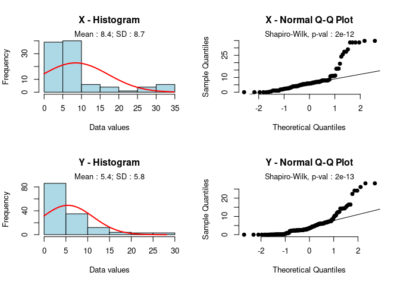

```r
sepfoo(Category, Data_Vitamins_Vitamin_K)
```

Для подавляющего большинства параметров не выполняются условия нормальности распределения (тест Шапиро-Уилка, QQ-plot) и одинаковости дисперсии между группами (тест Левина). Априори предположим, что имеет место независимость значений в выборке. Учитывая вышесказанное, кажется уместным для поиска разницы между группами (по переменной Category) использовать тест Манна-Уитни. Для параметра Data_Carbohydrate и Data_Major_Minerals_Zinc дополнительно будет применён t-тест c поправкой Уэлча (p.s: выглядят более менее прилично).

```r
func <- function (x) {with(cleaned_data, wilcox.test(x[Category == "Rice"], x[Category == "Cookie"]))[c("statistic", "p.value")]}

do.call(rbind, lapply(num_part_of_cd, function(x) func (x)))
```

```
##                                statistic p.value
## Data_Alpha_Carotene            11123.5   8.50543e-18
## Data_Beta_Carotene             11948.5   4.35776e-20
## Data_Beta_Cryptoxanthin        6835      0.2412422
## Data_Carbohydrate              0         3.981248e-40
## Data_Cholesterol               6719.5    0.3160814
## Data_Choline                   4541.5    1.317225e-06
## Data_Fiber                     3211      2.60071e-13
## Data_Lutein_and_Zeaxanthin     9384.5    3.184908e-05
## Data_Lycopene                  8593.5    3.89452e-06
## Data_Niacin                    3409.5    4.029143e-12
## Data_Protein                   1596      7.072975e-25
## Data_Retinol                   5512      0.00031024
## Data_Riboflavin                318       8.528726e-37
## Data_Selenium                  4529.5    1.167088e-06
## Data_Sugar_Total               431       1.224372e-35
## Data_Thiamin                   2647      6.790742e-17
## Data_Water                     14300     3.980513e-40
## Data_Fat_Monosaturated_Fat     375       3.338033e-36
## Data_Fat_Polysaturated_Fat     719       8.684614e-33
## Data_Fat_Saturated_Fat         606       6.856874e-34
## Data_Fat_Total_Lipid           362       2.448533e-36
## Data_Major_Minerals_Calcium    4788      1.169725e-05
## Data_Major_Minerals_Copper     1864.5    1.098611e-22
## Data_Major_Minerals_Iron       887.5     3.437394e-31
## Data_Major_Minerals_Magnesium  4709      5.824575e-06
## Data_Major_Minerals_Phosphorus 4424      4.298967e-07
## Data_Major_Minerals_Potassium  2433.5    2.19127e-18
## Data_Major_Minerals_Sodium     3371.5    2.437825e-12
## Data_Major_Minerals_Zinc       6221      0.08498116
## Data_Vitamins_Vitamin_A_RAE    9914.5    2.005246e-07
## Data_Vitamins_Vitamin_B12      4584      3.177608e-08
## Data_Vitamins_Vitamin_B6       10829     8.929251e-12
## Data_Vitamins_Vitamin_C        11016     4.774018e-14
## Data_Vitamins_Vitamin_E        3063      3.462062e-14
## Data_Vitamins_Vitamin_K        5290      0.0005620782
```

```r
t.test(data=cleaned_data, Data_Carbohydrate ~ Category)
```

```
##
##  Welch Two Sample t-test
##
## data:  Data_Carbohydrate by Category
## t = 61.913, df = 128.8, p-value < 2.2e-16
## alternative hypothesis: true difference in means between group Cookie and group Rice is not equal to 0
## 95 percent confidence interval:
##  44.66484 47.61381
## sample estimates:
## mean in group Cookie   mean in group Rice
##             68.08730             21.94797
```

```r
t.test(data=cleaned_data, Data_Major_Minerals_Zinc ~ Category)
```

```
##
##  Welch Two Sample t-test
##
## data:  Data_Major_Minerals_Zinc by Category
## t = 1.935, df = 162.68, p-value = 0.05473
## alternative hypothesis: true difference in means between group Cookie and group Rice is not equal to 0
## 95 percent confidence interval:
##  -0.001322471  0.130265128
## sample estimates:
## mean in group Cookie   mean in group Rice
##            0.6358000            0.5713287
```

За исключением некоторых переменных (Data_Beta_Cryptoxanthin, Data_Cholesterol, Data_Major_Minerals_Zinc) справедливо предположить, что две выборки (по переменной Category) взяты из распределений с разным средним в генеральной совокупности.

# Далее идут **необязательные** дополнительные задания, которые могут принести вам дополнительные баллы в том числе в случае ошибок в предыдущих

## Корреляционный анализ

1. Создайте корреляционную матрицу с визуализацией и поправкой на множественные сравнения. Объясните, когда лучше использовать корреляционные матрицы и в чём минусы и плюсы корреляционных исследований.

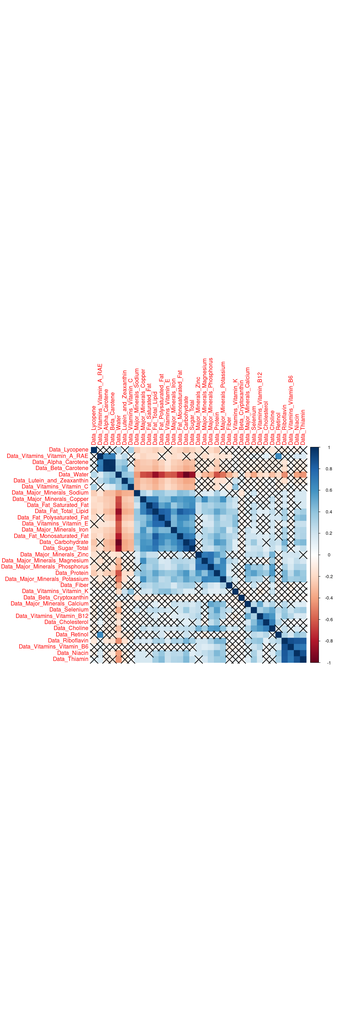

```r
cor_plot <- cleaned_data %>%
  select(starts_with("Data_")) %>%
  psych::corr.test(adjust = "BH")           #поправка Бенджамини — Хохберга

corrplot(corr = cor_plot$r,
         p.mat = cor_plot$p,
         method = "color",
         order = "hclust")
```

Крестиками отмечены статистические незначимые (с p.value > 0.05), без крестиков – статистически значимые коэффициенты корреляции.

Корреляционные матрицы преимущественно используются: 1) для удобного обобщения набора данных 2) для диагностики регрессии 3) в качестве исходных данных для других анализов, например исследовательский факторный анализ

Плюсы корреляционных исследований: - возможность изучить широкий диапазон переменных - дает информацию о направлении и силе взаимосвязи между переменным - исследование достаточно просто в реализации

Минусы: - мало возможностей для установления контроля над переменными - нет возможности проанализировать сложные взаимодействия между переменными, если они имеют место быть - выявленная корреляция не эквивалентна непосредственной каузальной связи

## Моделирование

1. Постройте регрессионную модель для переменной **Category**. Опишите процесс построения

```r
cleaned_data %>%
  mutate(Category2 = as.integer(ifelse(Category == "Cookie", 0, 1))) %>%
  relocate(Category2, .after=Category) %>%
  select(Category2, where(is.numeric)) %>%
  select(-Nutrient_Data_Bank_Number) -> cleaned_data_m

pre_model <- glm(data = cleaned_data_m, family = "binomial", Category2 ~ .)

# names(car::vif(pre_model))

model <- glm(data = cleaned_data_m, family = "binomial", Category2 ~ . -Data_Carbohydrate -Data_Vitamins_Vitamin_A_RAE -Data_Fat_Total_Lipid -Data_Beta_Carotene -Data_Water -Data_Riboflavin -Data_Vitamins_Vitamin_E -Data_Vitamins_Vitamin_B12 -Data_Protein -Data_Major_Minerals_Phosphorus -Data_Vitamins_Vitamin_B6 -Data_Major_Minerals_Zinc -Data_Major_Minerals_Copper -Data_Vitamins_Vitamin_K -Data_Fiber -Data_Thiamin -Data_Fat_Saturated_Fat -Data_Fat_Polysaturated_Fat -Data_Retinol -Data_Major_Minerals_Magnesium -Data_Choline -Data_Major_Minerals_Sodium)
```

Следующий шаг - проверка на линейность. Для этого отрисуем графики с logit по оси абцисс и значением той или иной числовой переменной, оставшейся после селекции на предыдущем шаге.

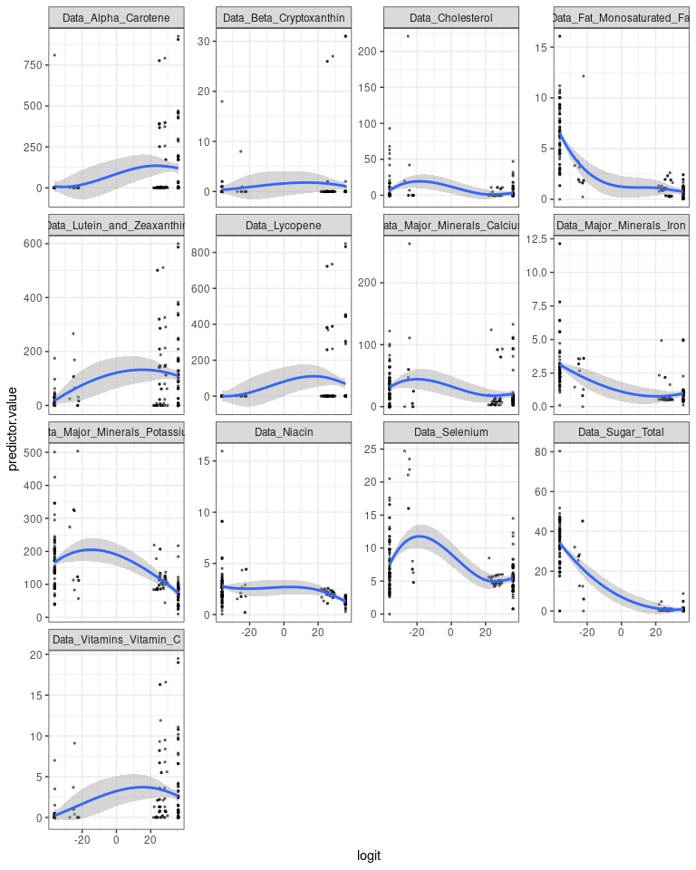

```r
probabilities <- predict(model, type = "response")
logit <- log(probabilities/(1-probabilities))
predictors <- names(car::vif(model))

cleaned_data_m1 <- cleaned_data_m %>% select(predictors)
cleaned_data_m1$logit <- logit

cleaned_data_m2 <- cleaned_data_m1 %>%
   gather(key = "predictors", value = "predictor.value", -logit)

ggplot(cleaned_data_m2, aes(logit, predictor.value))+
  geom_point(size = 0.5, alpha = 0.5) +
  geom_smooth(method = "loess") +
  theme_bw() +
  facet_wrap(~predictors, scales = "free_y", ncol=4)
```

Перемеенная Data_Selenium не свзана линейно с logit (~= как мне кажется), потому удалим этот предиктор.

```r
model2 <- glm(data = cleaned_data_m, family = "binomial", Category2 ~ Data_Alpha_Carotene + Data_Beta_Cryptoxanthin + Data_Cholesterol + Data_Lutein_and_Zeaxanthin + Data_Lycopene + Data_Niacin + Data_Sugar_Total + Data_Fat_Monosaturated_Fat + Data_Major_Minerals_Calcium + Data_Major_Minerals_Iron + Data_Major_Minerals_Potassium + Data_Vitamins_Vitamin_C)
```

Воспользуемся built-in функцией step(), чтобы найти наиболее значимые предикторы для предсказания **Category**. Будем ориентироваться на информационный критерий Акаике (чем меньше, тем лучше). Также посчитаем Байесовский критерий.

```r
best_model <- MASS::stepAIC(model2,trace = FALSE)
summary(best_model)
```

```
##
## Call:
## glm(formula = Category2 ~ Data_Sugar_Total + Data_Fat_Monosaturated_Fat,
##     family = "binomial", data = cleaned_data_m)
##
## Deviance Residuals:
##        Min          1Q      Median          3Q         Max
## -1.697e-04  -2.100e-08   2.100e-08   2.100e-08   2.254e-04
##
## Coefficients:
##                            Estimate Std. Error z value Pr(>|z|)
## (Intercept)                  124.57   15745.41   0.008    0.994
## Data_Sugar_Total             -11.23    1456.62  -0.008    0.994
## Data_Fat_Monosaturated_Fat   -40.78    5469.03  -0.007    0.994
##
## (Dispersion parameter for binomial family taken to be 1)
##
##     Null deviance: 3.2922e+02  on 242  degrees of freedom
## Residual deviance: 1.4783e-07  on 240  degrees of freedom
## AIC: 6
##
## Number of Fisher Scoring iterations: 25
```

```r
AIC(best_model)
```

```
## [1] 6
```

```r
BIC(best_model)
```

```
## [1] 16.47918
```